# Homework #2 - Data Exploration

Author

Jordan Sibley

Published

February 4, 2025

## Description

The purpose of this document is to begin to work with the data for the final project and do some data exploration. By the end, I will have cleaned and explored the data, create some initial plots, and begin to identify which types of visualizations are most appropriate for the data.

## Set Up

### Load packages

```r
library(tidyverse)
library(here)
library(janitor)
library(gridExtra)
```

### Read in Data

**About the data**

1. Kelp Data: SBC LTER: Reef: Kelp Forest Community Dynamics: Abundance and size of Giant Kelp (Macrocystis Pyrifera), ongoing since 2000. https://sbclter.msi.ucsb.edu/data/catalog/package/?package=knb-lter-sbc.18
2. Invertebrate Data: SBC LTER: Reef: Kelp Forest Community Dynamics: Invertebrate and algal density. https://sbclter.msi.ucsb.edu/data/catalog/package/?package=knb-lter-sbc.19
3. Fish Data: SBC LTER: Reef: Kelp Forest Community Dynamics: Fish abundance. https://sbclter.msi.ucsb.edu/data/catalog/package/?package=knb-lter-sbc.17

Metadata

4. SBC LTER: Reef: Master species list. https://sbclter.msi.ucsb.edu/data/catalog/package/?package=knb-lter-sbc.120

**Temporal & Geographic Info**

Time: 2000-08-01 to 2024-07-30

Sites:

Protected Sites

- NAPL: Naples Reef
- IVEE: Isla Vista (IV)

Non-Protected Sites

- ABUR: Arroyo Burro Reef
- AHND: Arroyo Hondo Reef
- AQUE: Arroyo Quemado Reef
- BULL: Builto
- CARP: Carpinteria Reef
- GOLB: Goleta Bay
- MOHK: Mohawk Reef
- SCDI: Santa Cruz Island, Diablo (Wont include)
- SCTW: Santa Cruz Island, Twin Harbor West (Wont include)

```r
# Read in SBC LTER datasets
kelp_all <- read_csv(here::here('data', 'Annual_Kelp_All_Years_20240823.csv'))

invert_all <- read_csv(here::here('data', 'Annual_Quad_Swath_All_Years_20240823.csv'))

fish_all <- read_csv(here::here('data', 'Annual_fish_comb_20240823.csv'))

species_list <- read_csv(here::here('data', 'SBCLTER_Species_List_Master_20210113.csv'))
```

## Data Cleaning

**Plan**

- Remove SCI sites
- Convert `-99999` values to `NA`
- Make columns lowercase

Create new datasets for:

- Purple Urchins
- Spiny lobsters
- CA Sheephead

```r
# Clean kelp data
kelp_clean <- kelp_all |>
  filter(SITE != "SCDI" & SITE != "SCTW") |>
  naniar::replace_with_na(replace = list(FRONDS = -99999)) |>
  naniar::replace_with_na(replace = list(HLD_DIAM = -99999)) |>
  janitor::clean_names()

# Clean invert data
invert_clean <- invert_all |>
  filter(SITE != "SCDI" & SITE != "SCTW") |>
  naniar::replace_with_na(replace = list(SIZE = -99999)) |>
  janitor::clean_names()

# Clean fish data
fish_clean <- fish_all |>
  filter(SITE != "SCDI" & SITE != "SCTW") |>
  naniar::replace_with_na(replace = list(SIZE = -99999)) |>
  naniar::replace_with_na(replace = list(COUNT = -99999)) |>
  janitor::clean_names()


# Purple Urchins
purp_urchin <- invert_clean |>
  filter(scientific_name == "Strongylocentrotus purpuratus")

# Spiny lobsters
lobster <- invert_clean |>
  filter(scientific_name == "Panulirus interruptus")

# CA sheephead
sheephead <- fish_clean |>
  filter(scientific_name == "Semicossyphus pulcher")
```

## Exploratory Plots

### 1. Total counts of four species over time

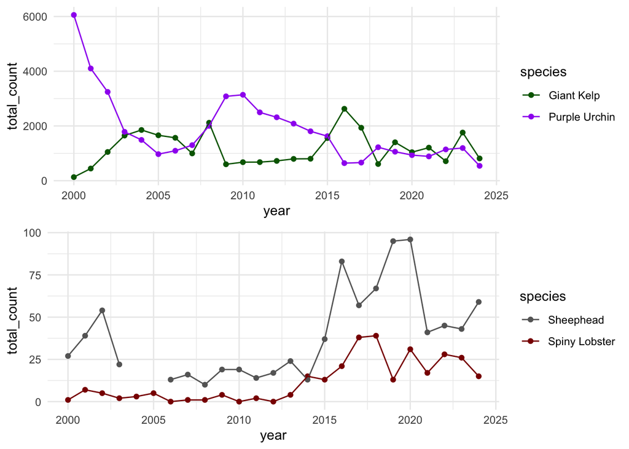

```r
# Group by year to get total count
kelp_total_count <- kelp_clean |>
  group_by(year) |>
  summarise(total_count = n()) |>
  mutate(species = "Giant Kelp")

purp_urchin_total_count <- purp_urchin |>
  group_by(year) |>
  summarise(total_count = sum(count)) |>
  mutate(species = "Purple Urchin")

lobster_total_count <- lobster |>
  group_by(year) |>
  summarise(total_count = sum(count)) |>
  mutate(species = "Spiny Lobster")

sheephead_total_count <- sheephead |>
  group_by(year) |>
  summarise(total_count = sum(count)) |>
  mutate(species = "Sheephead")

# New dataframe with all the total count data
spp_all_counts <- bind_rows(kelp_total_count,
                            purp_urchin_total_count,
                            lobster_total_count,
                            sheephead_total_count)

# Plot count over time Giant kelp & Purple urchin
p1 <- spp_all_counts |>
  filter(species == "Giant Kelp" | species == "Purple Urchin") |>
  ggplot(aes(x = year, y = total_count, color = species)) +
  geom_point() +
  geom_line() +
  scale_color_manual(values = c("Giant Kelp" = "darkgreen",
                                "Purple Urchin" = "purple")) +
  theme_minimal()

p2 <- spp_all_counts |>
  filter(species == "Sheephead" | species == "Spiny Lobster") |>
  ggplot(aes(x = year, y = total_count, color = species)) +
  geom_point() +
  geom_line() +
  scale_color_manual(values = c("Sheephead" = "grey40",
                                "Spiny Lobster" = "darkred")) +
  theme_minimal()

gridExtra::grid.arrange(p1, p2, ncol = 1)
```

### 2. Kelp densities at the sites

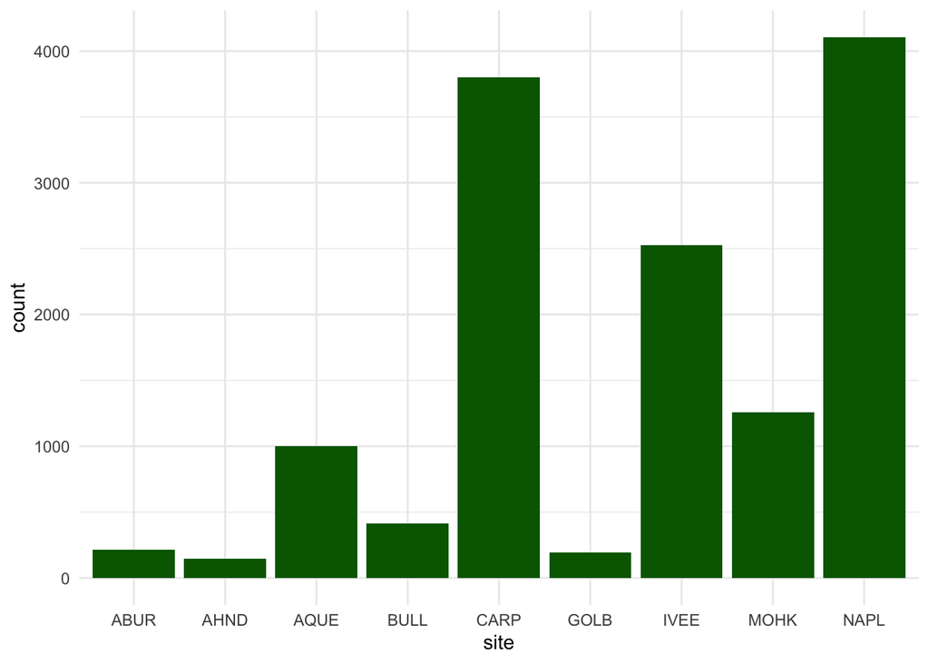

```r
kelp_density <- kelp_clean |>
  group_by(year, site, transect) |>
  summarise(count = n())


# Violin plot for 2015-2024
kelp_density |>
  filter(year >= 2015) |>
  ggplot(aes(x = site, y = count)) +
  geom_col(fill = "darkgreen") +
  theme_minimal()
```

It might be fun to do the bar graph and visualize it with giant kelp fronds!

### 3. Kelp and urchin counts at each site bar graph

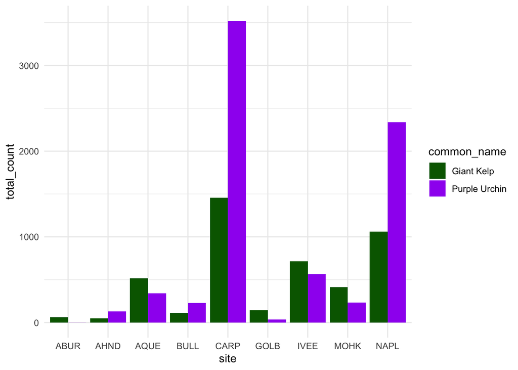

```r
kelp_compare <- kelp_clean |>
  group_by(year, site, common_name) |>
  summarise(total_count = n())

urchin_compare <- purp_urchin |>
  group_by(year, site, common_name) |>
  summarise(total_count = sum(count))

kelp_urch_compare <- bind_rows(kelp_compare, urchin_compare)

# Bar chart
ggplot(kelp_urch_compare, aes(x = site, y = total_count, fill = common_name)) +
  geom_col(position = "dodge") +
  scale_fill_manual(values = c("Giant Kelp" = "darkgreen",
                               "Purple Urchin" = "purple")) +
  theme_minimal()
```

## Questions to Respond to

1. What have you learned about your data? Have any potentially interesting patterns emerged?

After plotting some of my data, it seems that there could be some potential relationships between the species abundance trends over time. One thing I like about the datasets is how easy is it to combine them. The columns are clearing and uniformly named and the sites are the same.

2. In HW #1, you outlined some questions that you wanted to answer using these data. Have you made any strides towards answering those questions? If yes, how so? If no, what next steps do you need to take (e.g. I need to create X plot type, I still need to track down Y data, I need to restructure existing data so that you can visualize it in Z ways, etc.)?

I believe I am moving in the right direction to produce cohesive visualizations for my infographic. I don’t think I will need any additional data, unless I think of a specific visualization that would require it.

3. What challenges do you foresee encountering with your data? These can be data wrangling and / or visualization challenges.

One challenge I think I will face is knowing how much information to include and when to claim a relation is present or not. Additionally, some of the species abundance trends might be related to environmental variables or fishing pressure, which is not data I was intending on including.